# cdmetapopR Vignette

## 7.2 Size Histogram

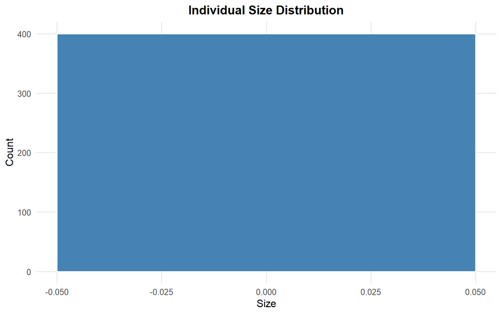

```r
summary_ind(ex_dir, type = "size", year = 9, batch = 0, mc = 0)
```

## 7.3 Size by Age

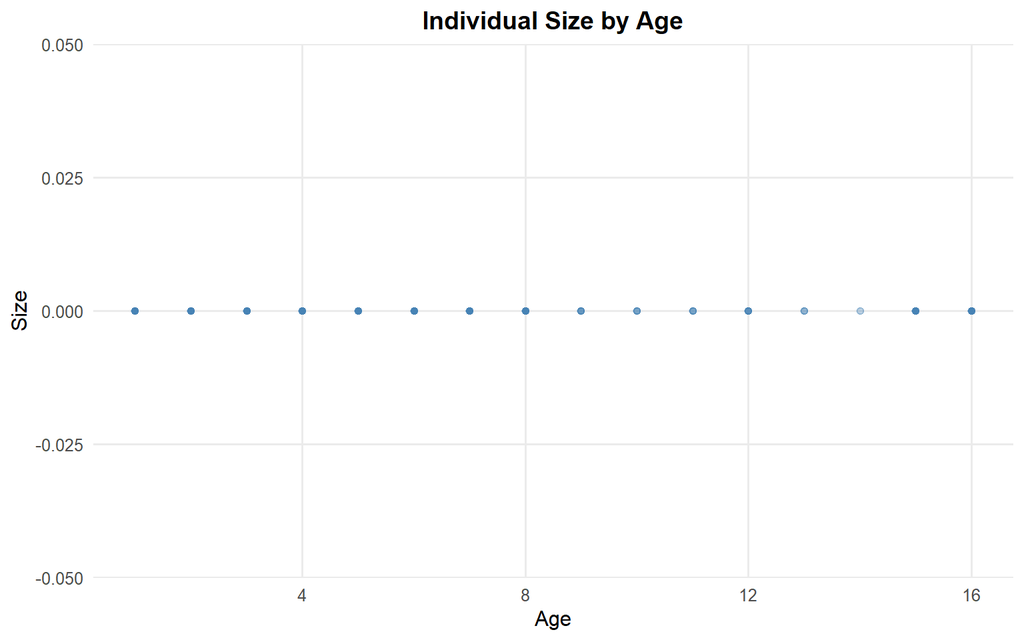

```r
summary_ind(ex_dir, type = "age_size", year = 9, batch = 0, mc = 0)
```

Filter to a subset of patches with `patches`.

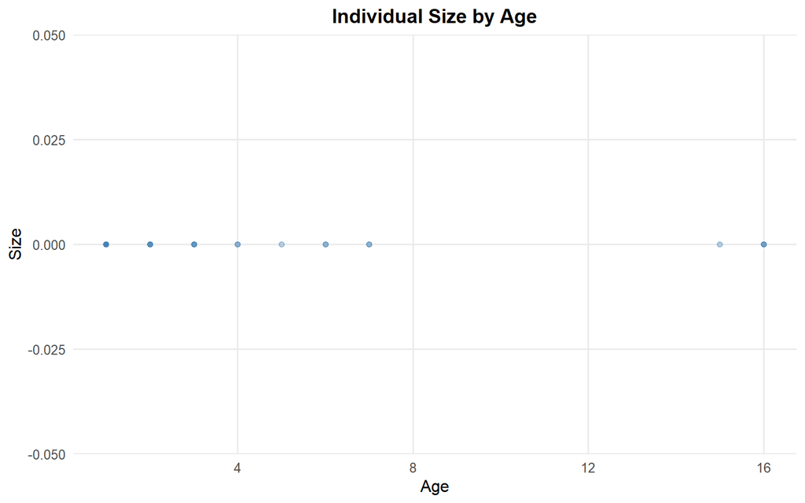

```r
summary_ind(ex_dir, type = "age_size", year = 9, batch = 0, mc = 0, patches = c(1, 3, 4, 5))
```

## 7.4 Hindex Histogram

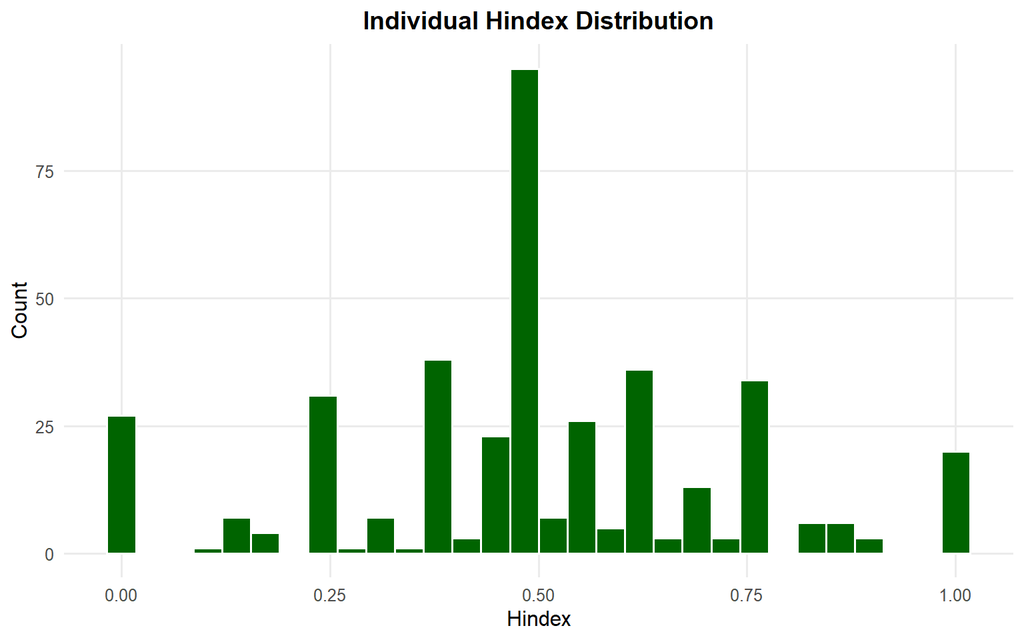

```r
summary_ind(ex_dir, type = "hindex", year = 9, batch = 0, mc = 0)
```

## 7.5 Movement Distance Histogram

`CDist = -9999` is treated as no movement and is excluded from the histogram.

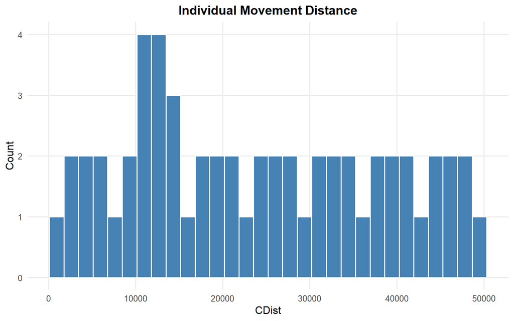

```r
summary_ind(ex_dir, type = "cdist", year = 9, batch = 0, mc = 0)
```

## 7.6 Movement Over Time

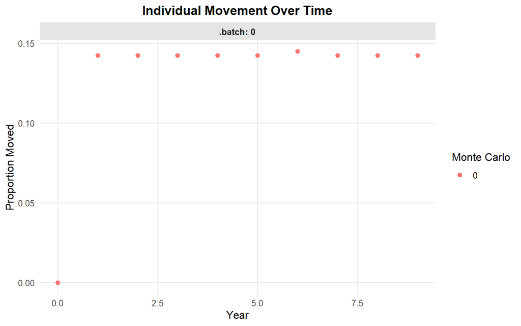

```r
summary_ind(ex_dir, type = "movement", years = 0:9, batch = 0, mc = 0)
```

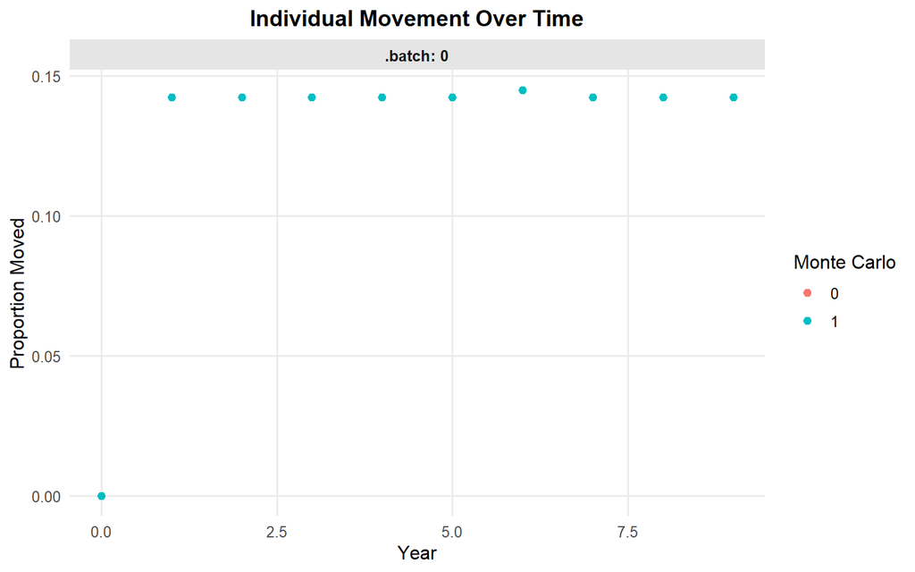

```r
summary_ind(ex_dir, type = "movement", years = 0:9, batch = 0, mc = "all")
```

If CDMetaPOP output includes sampled individual files, use `file_type = "ind_Sample"` to read `ind##_Sample.csv` files instead of `ind##.csv` files. The bundled example data use `ind##.csv`, so this example is shown but not evaluated.

```r
summary_ind(ex_dir, type = "age", year = 9, file_type = "ind_Sample")
```

# 8 Individual-Level Genetics

The individual-level genetics functions use genotype columns named like `L0A0`, `L0A1`, `L1A0`, and so on.

## 8.1 Allele Frequencies by Patch

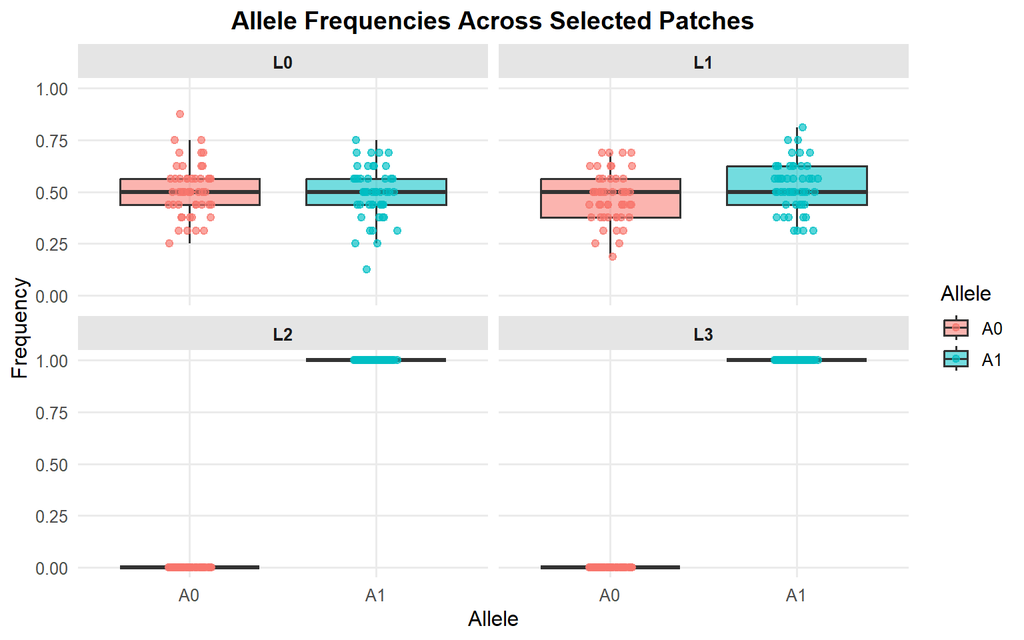

```r
allele_frequencies_ind(ex_dir, year = 9, batch = 0, mc = 0)
```

Focus on one locus with `loci`.

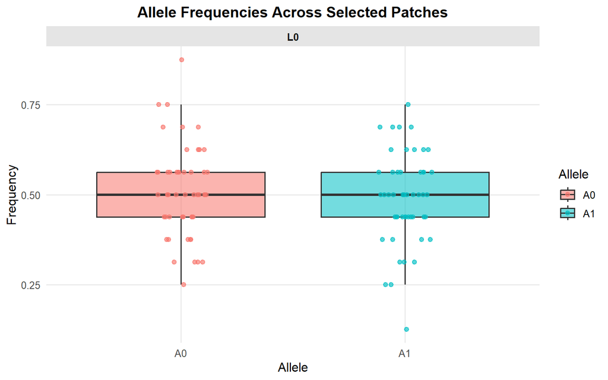

```r
allele_frequencies_ind(ex_dir, year = 9, batch = 0, mc = 0, loci = "L0")
```

Filter to selected patches when a figure would otherwise be too dense.

```r
allele_frequencies_ind(
  ex_dir,
  year = 9,
  batch = 0,
  mc = 0,
  loci = "L0",
  patches = c(1, 3, 4, 5, 7, 9)#,
  #jitter = FALSE
)
```

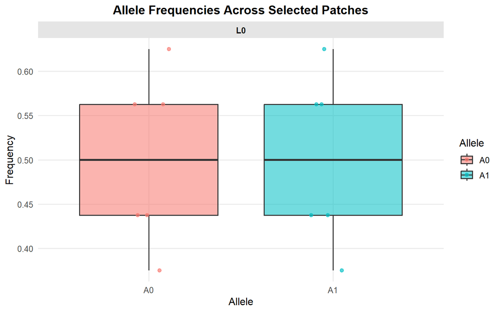

Jittering of points on top of the boxplots can be turned off by adding the argument jitter = FALSE.

## 8.2 Heterozygosity by Patch

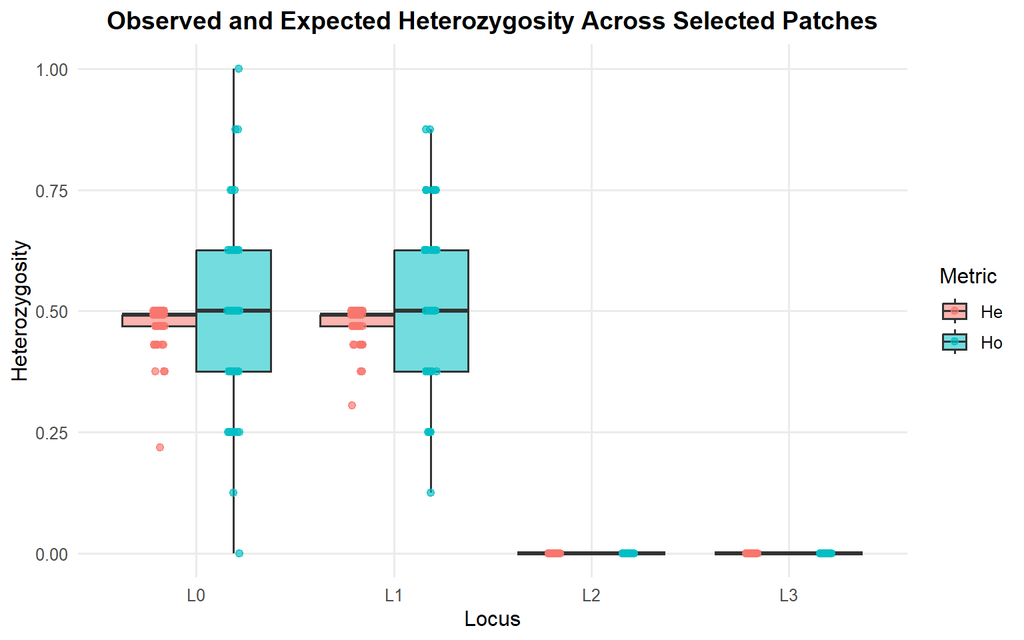

```r
heterozygosity_ind(ex_dir, year = 9, batch = 0, mc = 0)
```

```r
heterozygosity_ind(
  ex_dir,
  year = 9,
  batch = 0,
  mc = 0,
  loci = "L0",
  patches = c(1, 3, 4, 5, 7, 9)
)
```

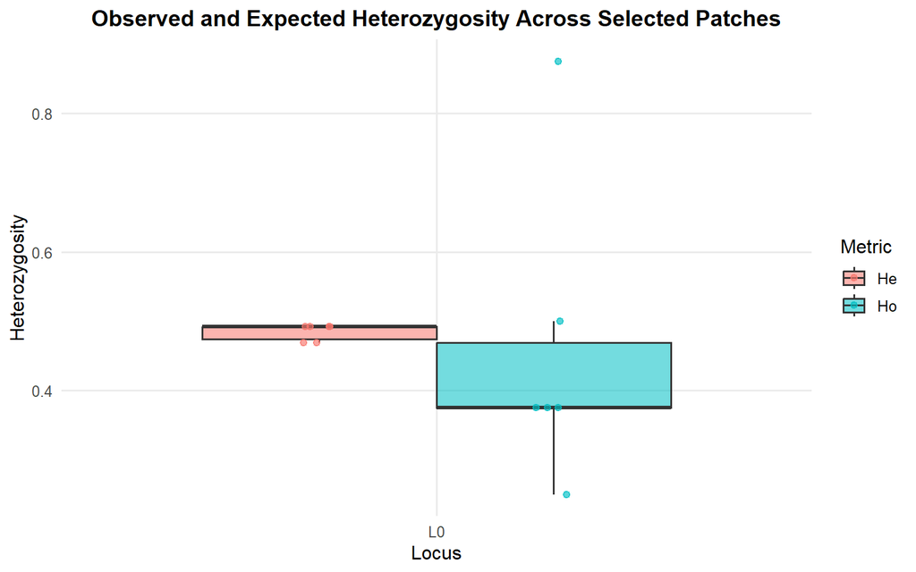

## 8.3 Pairwise FST

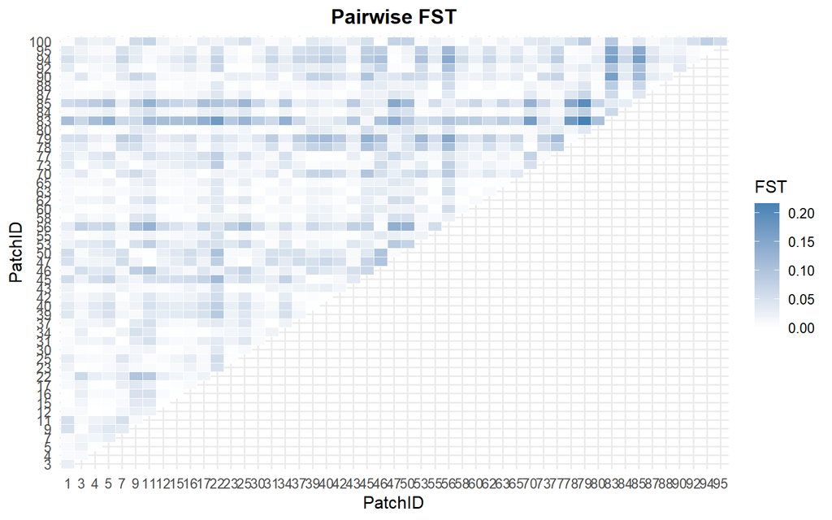

```r
pairwise_fst_ind(ex_dir, year = 9, batch = 0, mc = 0)
```

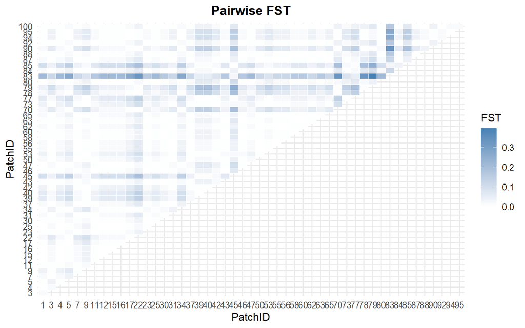

```r
pairwise_fst_ind(ex_dir, year = 9, batch = 0, mc = 0, loci = "L0")
```

# 9 Patch Maps from Individual Files

`summary_patch_map()` maps patch locations from the individual files. Point size reflects the number of individuals in each patch.

## 9.1 All Individuals

```r
summary_patch_map(
  ex_dir,
  years = c(0, 5, 9),
  batch = 0,
  mc = 0,
  crs = 5070
)
```

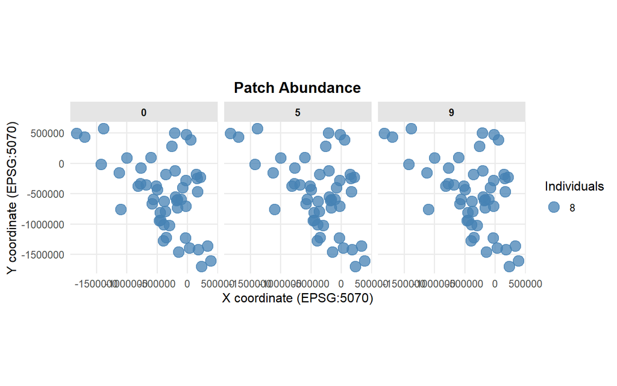

If patch counts vary widely, use `log_scale = TRUE` for abundance point sizes.

```r
summary_patch_map(
  ex_dir,
  years = c(0, 5, 9),
  batch = 0,
  mc = 0,
  log_scale = TRUE,
  crs = 5070
)
```

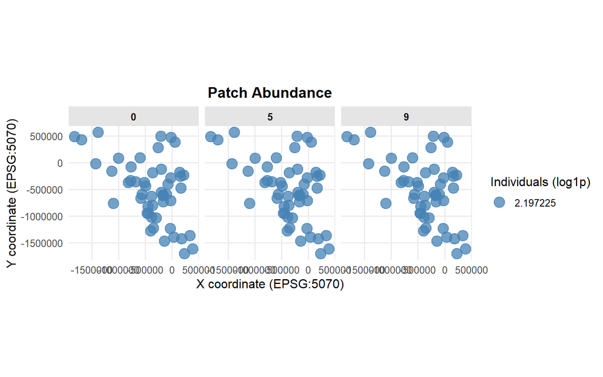

## 9.2 One Disease State

Use `states` to count only individuals in selected disease states.

```r
summary_patch_map(
  ex_dir,
  years = c(0, 5, 9),
  batch = 0,
  mc = 0,
  states = 1,
  crs = 5070
)
```

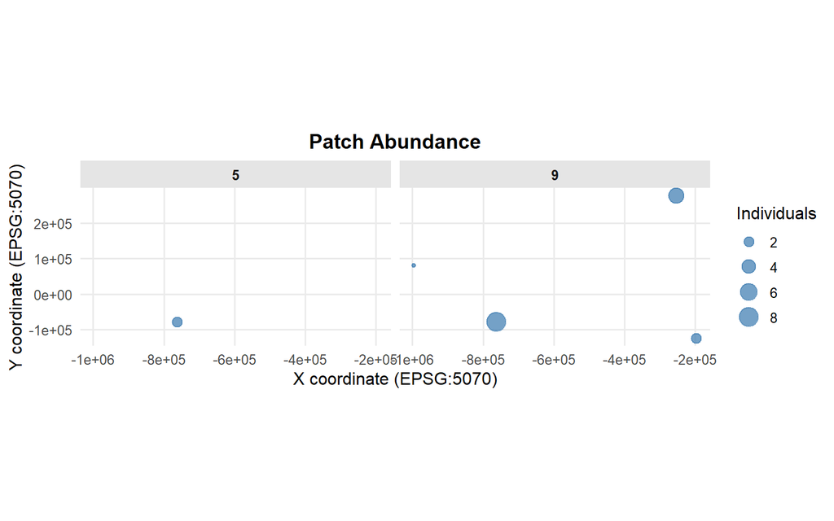

## 9.3 Faceted by Disease State

```r
summary_patch_map(
  ex_dir,
  years = c(0, 9),
  batch = 0,
  mc = 0,
  states = c(0, 1),
  facet_by_state = TRUE,
  crs = 5070
)
```

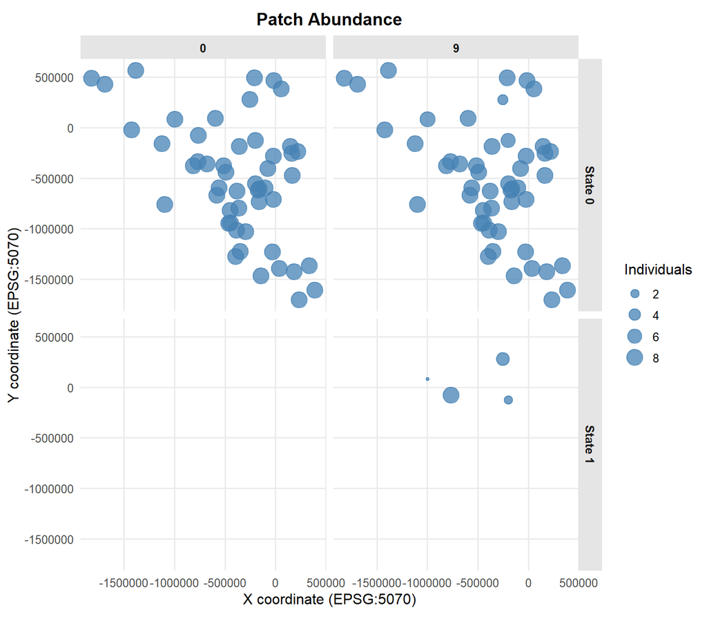

## 9.4 Allele Frequency Map

Patch maps can also show genetic summaries from individual files. For allele frequency maps, specify one `locus` and one `allele`.

```r
summary_patch_map(
  ex_dir,
  type = "allele_frequency",
  years = 9,
  batch = 0,
  mc = 0,
  locus = "L0",
  allele = "A1",
  crs = 5070
)
```

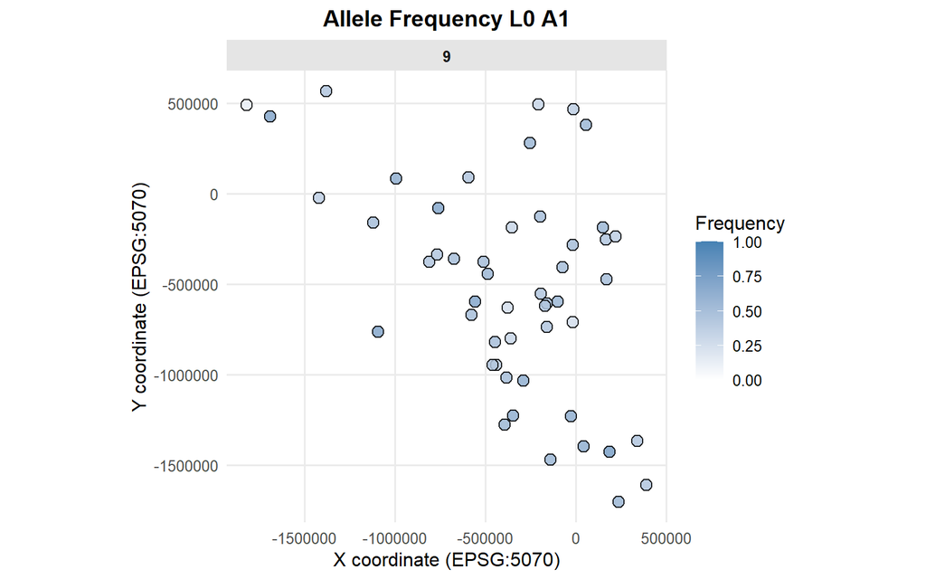

## 9.5 Heterozygosity Map

```r
summary_patch_map(
  ex_dir,
  type = "heterozygosity",
  years = 9,
  batch = 0,
  mc = 0,
  locus = "L0",
  metric = "Ho",
  crs = 5070
)
```

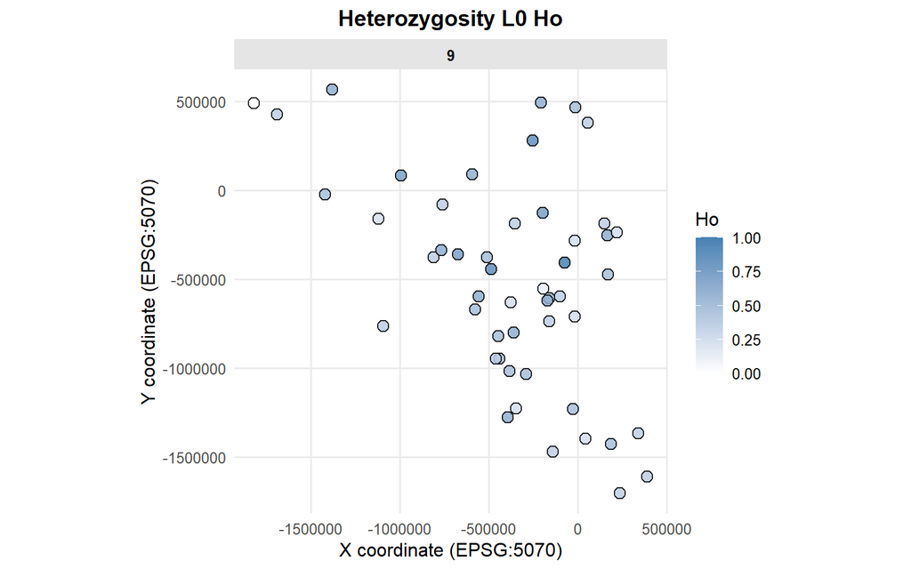

# 10 Older Summary Helpers

These functions are still exported and can be useful for specific legacy workflows.

## 10.1 `age_structure_proportions()`

```r
age_structure_proportions(
  path = paste0(ex_dir, "/"),
  runs = 1,
  gen = 9,
  species = 0
)
```

```
##               MC1         Avg
## Age1  0.498127341 0.498127341
## Age2  0.202247191 0.202247191
## Age3  0.153558052 0.153558052
## Age4  0.116104869 0.116104869
## Age5  0.082397004 0.082397004
## Age6  0.074906367 0.074906367
## Age7  0.063670412 0.063670412
## Age8  0.052434457 0.052434457
## Age9  0.014981273 0.014981273
## Age10 0.011235955 0.011235955
## Age11 0.011235955 0.011235955
## Age12 0.018726592 0.018726592
## Age13 0.007490637 0.007490637
## Age14 0.003745318 0.003745318
## Age15 0.044943820 0.044943820
## Age16 0.142322097 0.142322097
```

## 10.2 `dispersal()`

With `plot = FALSE`, `dispersal()` returns a data frame of movement proportions.

```r
dispersal(
  path = paste0(ex_dir, "/"),
  run = 0,
  batch = 0,
  mc = 1,
  gen = 9,
  species = 0,
  plot = FALSE
)
```

```
##    run0batch0mc0species0 run0batch0mc1species0
## Y0                0.0000                0.0000
## Y1                0.1425                0.1425
## Y2                0.1425                0.1425
## Y3                0.1425                0.1425
## Y4                0.1425                0.1425
## Y5                0.1425                0.1425
## Y6                0.1450                0.1450
## Y7                0.1425                0.1425
## Y8                0.1425                0.1425
## Y9                0.1425                0.1425
```

With `plot = TRUE`, it draws a base R barplot and returns the same kind of summary.

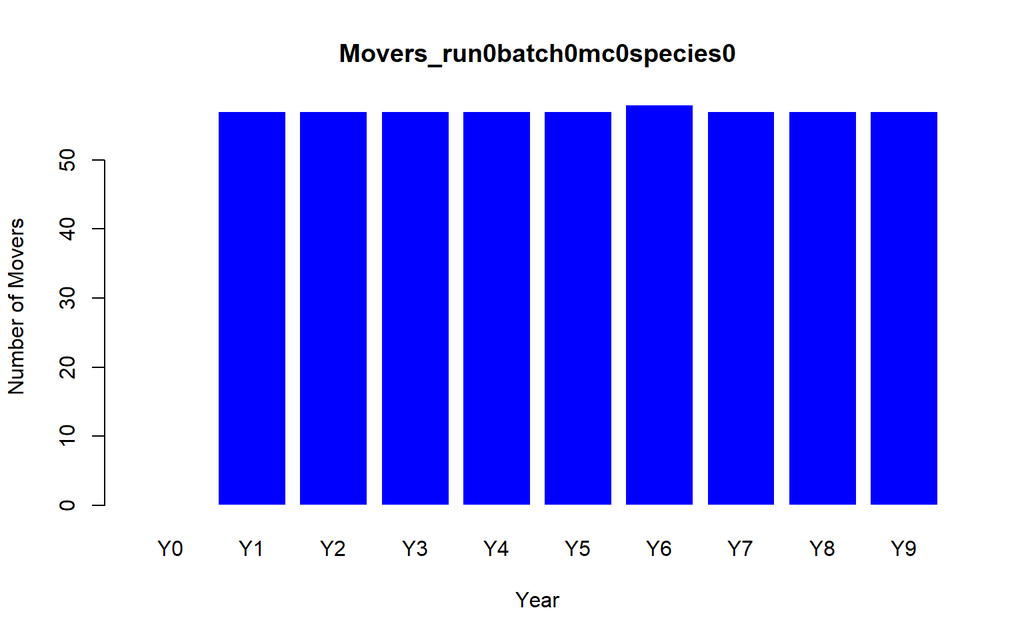

```
##    Year movers
## 1     0      0
## 2     1     57
## 3     2     57
## 4     3     57
## 5     4     57
## 6     5     57
## 7     6     58
## 8     7     57
## 9     8     57
## 10    9     57
```

```r
dispersal(
  path = paste0(ex_dir, "/"),
  run = 0,
  batch = 0,
  mc = 0,
  gen = 9,
  species = 0,
  plot = TRUE
)
```

## 10.3 `hets_plot()`

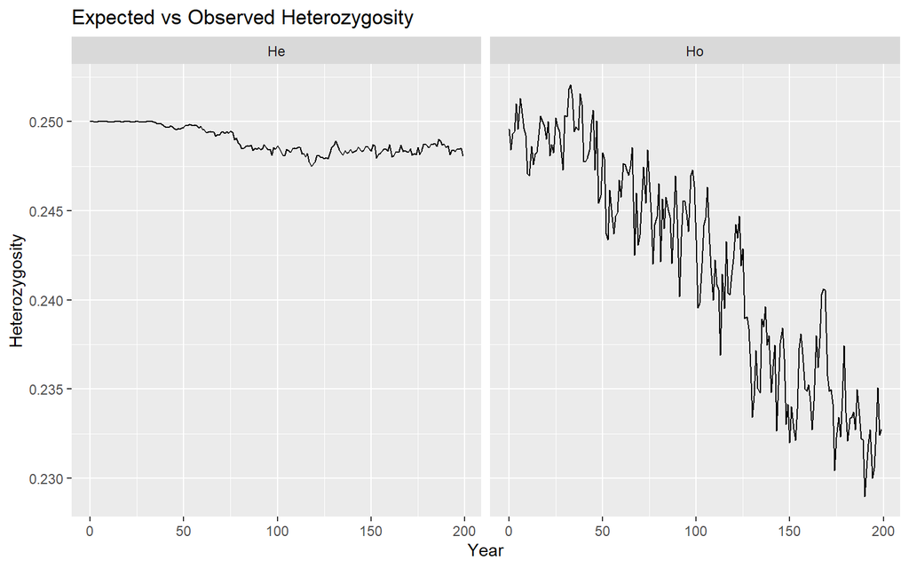

```r
summary_pop_single <- read.csv(pop_file)
hets_plot(summary_pop_single)
```

## 10.4 `alleles_by_year()`

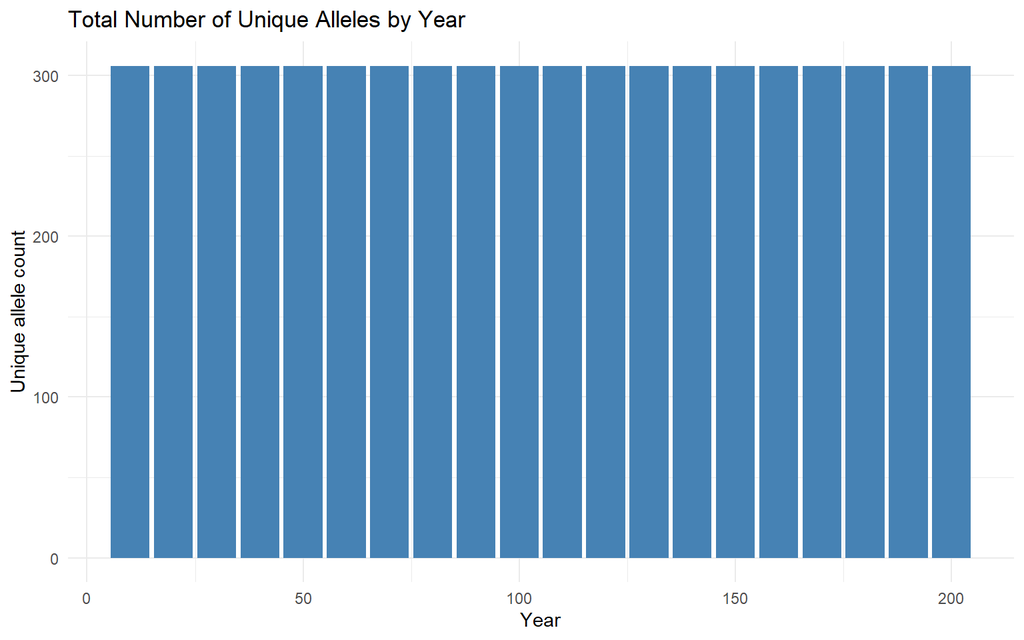

```r
alleles_by_year(summary_pop_single, n = 10)
```

## 10.5 `size_age_class()`

[figure not shown]

```r
size_age_class(class_file)
```

# 11 Interactive and External-Run Functions

The following functions are exported, but they launch external software or interactive Shiny apps. They are shown here as code examples but are not run while knitting this document.

## 11.1 `launch_cdmetapop()`

```r
launch_cdmetapop(
  pythonFilepath = "C:/path/to/python.exe",
  CDMetaPOPFilepath = "C:/path/to/CDMetaPOP.py",
  runvarsDirectory = "C:/path/to/example_files/",
  runvarsFilename = "RunVars.csv",
  outputDirectory = "test_output"
)
```

## 11.2 Template Editors

```r
write_runvars(output_file = "my_new_runvars.csv")
write_popvars(output_file = "my_new_popvars.csv")
write_patchvars(output_file = "my_new_patchvars.csv")
write_classvars(output_file = "my_new_classvars.csv")
```

# 12 Deprecated Internal Compatibility Function

`locus()` is exported for compatibility with older `gstudio` workflows. It is included in the package because the original function is deprecated elsewhere.

```r
locus(c("0", "1"), type = "snp")
```

```
## [1] "A:A" "A:B"
## attr(,"class")
## [1] "locus"
```